# Context valence analysis

anonymous

16/06/2021

## Setup

Load packages:

```r
library(tidyverse) # for data processing
library(brms) # for bayesian models
library(effsize) # for cohen's d
library(patchwork) # for double plots
library(tidybayes) # for half-eye plots
```

Load data:

```r
words <- read_csv('../data/key_words.csv')

words
```

```
## # A tibble: 14 × 3
##    word        pair                 type
##    <chr>       <chr>                <chr>
##  1 add         add/subtract         add
##  2 subtract    add/subtract         subtract
##  3 addition    addition/subtraction add
##  4 subtraction addition/subtraction subtract
##  5 plus        plus/minus           add
##  6 minus       plus/minus           subtract
##  7 more        more/less            add
##  8 less        more/less            subtract
##  9 most        most/least           add
## 10 least       most/least           subtract
## 11 many        many/few             add
## 12 few         many/few             subtract
## 13 increase    increase/decrease    add
## 14 decrease    increase/decrease    subtract
```

Load the Snefjella & Kuperman norms

```r
snef <- read_delim('../data/snefjella_kuperman_context_valence.csv',
                 delim = ' ')
```

Get the overlap:

```r
words <- left_join(words, snef,
                   by = c('word' = 'Word'))
```

## Descriptive statistics

Check overall valence:

```r
words %>%
  group_by(type) %>%
  summarize(M = mean(Context_Valence, na.rm = TRUE),
            SD = sd(Context_Valence, na.rm = TRUE))
```

```
## # A tibble: 2 × 3
##   type         M     SD
##   <chr>    <dbl>  <dbl>
## 1 add       5.61 0.0696
## 2 subtract  5.55 0.102
```

Pairs that have missing values:

```r
bad_pairs <- filter(words,
                    is.na(Context_Valence))$pair
```

Perform Cohen’s d:

```r
add_val <- filter(words,
                  !(pair %in% bad_pairs),
                  type == 'add')$Context_Valence
subtract_val <- filter(words,
                       !(pair %in% bad_pairs),
                       type == 'subtract')$Context_Valence

# All four of them are more positive:

add_val - subtract_val
```

```
## [1] 0.017 0.026 0.196 0.150
```

```r
# Effect size:

cohen.d(add_val, subtract_val, paired = TRUE)
```

```
##
## Cohen's d
##
## d estimate: 0.9368735 (large)
## 95 percent confidence interval:
##      lower      upper
## -0.3290094  2.2027565
```

Get the values for the annotations:

```r
annotations <- tibble(context_val = subtract_val,
                      pair_label = filter(words,
                                          !(pair %in% bad_pairs),
                                          type == 'add')$pair)
```

Make a plot of this:

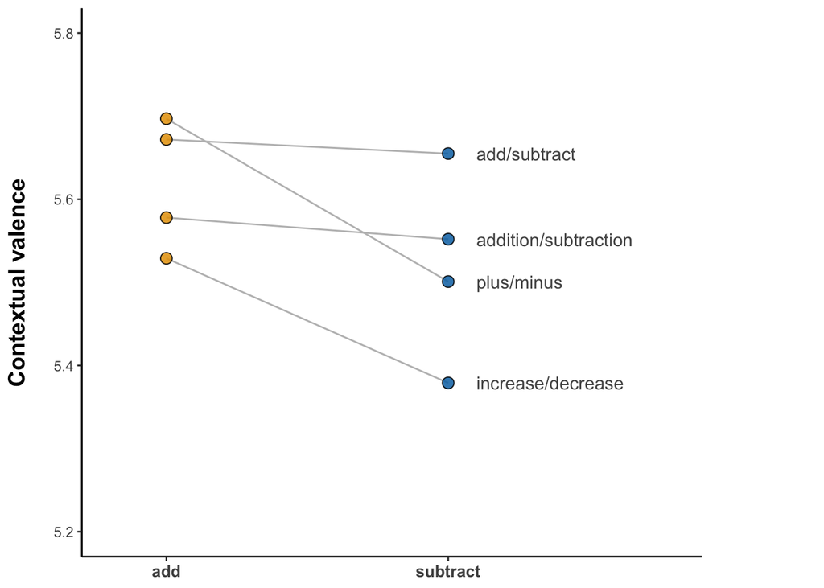

```r
# Define plot and aesthetics:

val_p <- filter(words, !(pair %in% bad_pairs)) %>%
  ggplot(aes(x = type, y = Context_Valence, fill = type, group = pair))

# Add geoms:

val_p <- val_p +
  geom_line(col = 'grey') +
  geom_point(size = 3, shape = 21, alpha = 0.85) +
  annotate(geom = 'text',
           x = rep(2.1, nrow(annotations)),
           y = annotations$context_val,
           label = annotations$pair_label,
           hjust = 0,
           col = 'grey33')

# Add scales and axes labels:

val_p <- val_p +
  scale_y_continuous(breaks = seq(5.2, 5.8, 0.2)) +
  scale_fill_manual(values = c("#E69F00", "#0072B2")) +
  coord_cartesian(xlim = c(1.3, 2.3), ylim = c(5.2, 5.8),
                  clip = 'off') +
  xlab(NULL) +
  ylab('Contextual valence')

# Add themes:

val_p <- val_p +
  theme_classic() +
  theme(legend.position = 'none') +
  theme(axis.title.y = element_text(margin = margin(t = 0, r = 15,
                                                    b = 0, l = 0),
                                    size = 14, face = 'bold'),
        axis.text.x = element_text(face = 'bold', size = 10),
        plot.margin = margin(r = 75, l = 5, b = 5, t = 5))

# Show and save:

val_p
```

```r
ggsave(plot = val_p,
       filename = '../figures/pdf/context_valence.pdf',
       width = 4, height = 4)

ggsave(plot = val_p,
       filename = '../figures/png/context_valence.png',
       width = 4, height = 4)

ggsave(plot = val_p,
       filename = '../figures/tiff/context_valence.tiff',
       width = 4, height = 4)
```

## Bayesian model

Make subtract the reference level of the `type` column. I’d wager it’s easier to think about stuff moving towards addition, which also gives us positive rather than negative coefficients.

```r
words <- mutate(words,
               type = factor(type, levels = c('subtract', 'add')))
```

Prior specifications:

```r
my_prior <- prior(normal(0, 0.05), class = 'b')
```

```r
val_mdl <- brm(Context_Valence ~ 1 + type + (1|pair),
               data = words,

               prior = my_prior,
               family = gaussian,

               # MCMC settings:

               seed = 42, chains = 4, cores = 4,
               warmup = 4000, iter = 6000,
               control = list(adapt_delta = 0.99))
```

Save the model:

```r
save(val_mdl, file = '../models/valence_model.RData')
```

Check the model:

```r
val_mdl
```

```
##  Family: gaussian
##   Links: mu = identity; sigma = identity
## Formula: Context_Valence ~ 1 + type + (1 | pair)
##    Data: words (Number of observations: 11)
##   Draws: 4 chains, each with iter = 6000; warmup = 4000; thin = 1;
##          total post-warmup draws = 8000
##
## Group-Level Effects:
## ~pair (Number of levels: 7)
##               Estimate Est.Error l-95% CI u-95% CI Rhat Bulk_ESS Tail_ESS
## sd(Intercept)     0.07      0.05     0.00     0.18 1.00     2081     2774
##
## Population-Level Effects:
##           Estimate Est.Error l-95% CI u-95% CI Rhat Bulk_ESS Tail_ESS
## Intercept     5.57      0.04     5.48     5.66 1.00     3613     3741
## typeadd       0.04      0.04    -0.04     0.10 1.00     4984     5113
##
## Family Specific Parameters:
##       Estimate Est.Error l-95% CI u-95% CI Rhat Bulk_ESS Tail_ESS
## sigma     0.09      0.03     0.04     0.16 1.00     2547     3743
##
## Draws were sampled using sampling(NUTS). For each parameter, Bulk_ESS
## and Tail_ESS are effective sample size measures, and Rhat is the potential
## scale reduction factor on split chains (at convergence, Rhat = 1).
```

```r
hypothesis(val_mdl, 'typeadd < 0')
```

```
## Hypothesis Tests for class b:
##      Hypothesis Estimate Est.Error CI.Lower CI.Upper Evid.Ratio Post.Prob Star
## 1 (typeadd) < 0     0.04      0.04    -0.03     0.09       0.22      0.18
## ---
## 'CI': 90%-CI for one-sided and 95%-CI for two-sided hypotheses.
## '*': For one-sided hypotheses, the posterior probability exceeds 95%;
## for two-sided hypotheses, the value tested against lies outside the 95%-CI.
## Posterior probabilities of point hypotheses assume equal prior probabilities.
```

Or the reverse, depending on how things are ought to be reported:

```r
hypothesis(val_mdl, 'typeadd > 0')
```

```
## Hypothesis Tests for class b:
##      Hypothesis Estimate Est.Error CI.Lower CI.Upper Evid.Ratio Post.Prob Star
## 1 (typeadd) > 0     0.04      0.04    -0.03     0.09       4.54      0.82
## ---
## 'CI': 90%-CI for one-sided and 95%-CI for two-sided hypotheses.
## '*': For one-sided hypotheses, the posterior probability exceeds 95%;
## for two-sided hypotheses, the value tested against lies outside the 95%-CI.
## Posterior probabilities of point hypotheses assume equal prior probabilities.
```

Visualize the posterior distribution of the `type` effect:

```r
val_samples <- posterior_samples(val_mdl)
```

Plot this:

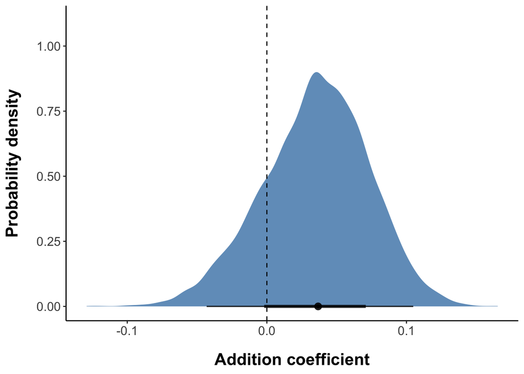

```r
# Plot basics:

post_p <- val_samples %>%
  ggplot(aes(x = b_typeadd)) +
  stat_halfeye(fill = 'steelblue', alpha = 0.8) +
  geom_vline(xintercept = 0, linetype = 'dashed')

# Axis and labels:

post_p <- post_p +
  xlab('Addition coefficient') +
  ylab('Probability density') +
  coord_cartesian(y = c(0, 1.1)) +
  scale_y_continuous(breaks = seq(0, 1, 0.25))

# Cosmetics:

post_p <- post_p +
  theme_classic() +
  theme(axis.text.x = element_text(size = 12),
        axis.text.y = element_text(size = 12),
        axis.title.x = element_text(face = 'bold', size = 16,
                                    margin = margin(t = 15)),
        axis.title.y = element_text(face = 'bold', size = 16,
                                    margin = margin(r = 15)))

# Show and save:

post_p
```

```r
ggsave(plot = post_p, filename = '../figures/pdf/valence_posterior.pdf',
       width = 7, height = 5)

ggsave(plot = post_p, filename = '../figures/png/valence_posterior.png',
       width = 7, height = 5)

ggsave(plot = post_p, filename = '../figures/tiff/valence_posterior.tiff',
       width = 7, height = 5)
```

## Posterior predictive checks

First, the regular `pp_check()` function, continuous:

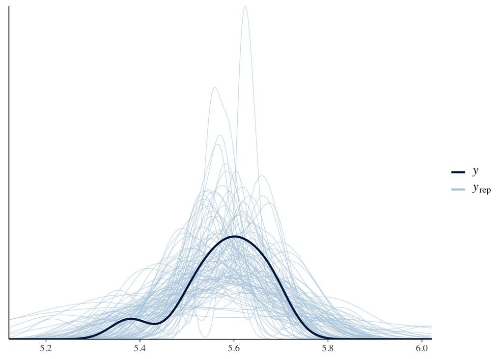

```r
pp_check(val_mdl, nsample = 100)
```

Looks OK.

## Put both into a double plot

Put the raw valence values and the posterior into a double plot:

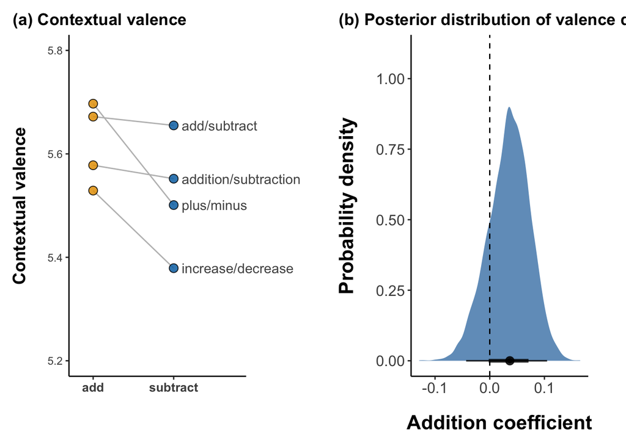

```r
val_p <- val_p +
  ggtitle('(a) Contextual valence') +
  theme(plot.title = element_text(face = 'bold'),
        plot.title.position = 'plot')

post_p <- post_p +
  ggtitle('(b) Posterior distribution of valence difference') +
  theme(plot.title = element_text(face = 'bold'),
        plot.margin = margin(r = 25),
        plot.title.position = 'plot')

# Combine:

both_p <- val_p + post_p

# Show and save:

both_p
```

```r
ggsave(filename = '../figures/pdf/valence_double_plot.pdf',
       width = 10, height = 4.5)

ggsave(filename = '../figures/png/valence_double_plot.png',
       width = 10, height = 4.5)

ggsave(filename = '../figures/tiff/valence_double_plot.tiff',
       width = 10, height = 4.5)
```

## Sensitivity analysis to assess impact of different prior choices

Create more extreme (= even more conservative) priors:

```r
weaker_prior <- prior(normal(0, 0.1), class = 'b')
stronger_prior <- prior(normal(0, 0.01), class = 'b')
even_stronger_prior <- prior(normal(0, 0.005), class = 'b')
```

```r
# Weaker than the model we chose, SD = 0.1:

val_mdl_weaker <- brm(Context_Valence ~ 1 + type + (1|pair),
                      data = words,

                      prior = weaker_prior,
                      family = gaussian,

                      # MCMC settings:

                      seed = 42, chains = 4, cores = 4,
                      warmup = 4000, iter = 6000,
                      control = list(adapt_delta = 0.99))
# Stronger than the model we chose, SD = 0.01:

val_mdl_stronger <- brm(Context_Valence ~ 1 + type + (1|pair),
                        data = words,

                        prior = stronger_prior,
                        family = gaussian,

                        # MCMC settings:

                        seed = 42, chains = 4, cores = 4,
                        warmup = 4000, iter = 6000,
                        control = list(adapt_delta = 0.99))
# Even stronger than the model we chose, SD = 0.005:

val_mdl_more_stronger <- brm(Context_Valence ~ 1 + type + (1|pair),
                             data = words,

                             prior = even_stronger_prior,
                             family = gaussian,

                             # MCMC settings:

                             seed = 42, chains = 4, cores = 4,
                             warmup = 4000, iter = 6000,
                             control = list(adapt_delta = 0.99))
```

Check models:

```r
val_mdl_weaker
```

```
##  Family: gaussian
##   Links: mu = identity; sigma = identity
## Formula: Context_Valence ~ 1 + type + (1 | pair)
##    Data: words (Number of observations: 11)
##   Draws: 4 chains, each with iter = 6000; warmup = 4000; thin = 1;
##          total post-warmup draws = 8000
##
## Group-Level Effects:
## ~pair (Number of levels: 7)
##               Estimate Est.Error l-95% CI u-95% CI Rhat Bulk_ESS Tail_ESS
## sd(Intercept)     0.07      0.05     0.00     0.20 1.00     1867     2811
##
## Population-Level Effects:
##           Estimate Est.Error l-95% CI u-95% CI Rhat Bulk_ESS Tail_ESS
## Intercept     5.56      0.05     5.46     5.65 1.00     3049     3029
## typeadd       0.06      0.05    -0.04     0.15 1.00     4792     4874
##
## Family Specific Parameters:
##       Estimate Est.Error l-95% CI u-95% CI Rhat Bulk_ESS Tail_ESS
## sigma     0.08      0.03     0.04     0.16 1.00     2274     4044
##
## Draws were sampled using sampling(NUTS). For each parameter, Bulk_ESS
## and Tail_ESS are effective sample size measures, and Rhat is the potential
## scale reduction factor on split chains (at convergence, Rhat = 1).
```

```r
val_mdl_stronger
```

```
##  Family: gaussian
##   Links: mu = identity; sigma = identity
## Formula: Context_Valence ~ 1 + type + (1 | pair)
##    Data: words (Number of observations: 11)
##   Draws: 4 chains, each with iter = 6000; warmup = 4000; thin = 1;
##          total post-warmup draws = 8000
##
## Group-Level Effects:
## ~pair (Number of levels: 7)
##               Estimate Est.Error l-95% CI u-95% CI Rhat Bulk_ESS Tail_ESS
## sd(Intercept)     0.06      0.05     0.00     0.17 1.00     2436     3554
##
## Population-Level Effects:
##           Estimate Est.Error l-95% CI u-95% CI Rhat Bulk_ESS Tail_ESS
## Intercept     5.58      0.04     5.49     5.66 1.00     3964     3224
## typeadd       0.00      0.01    -0.02     0.02 1.00     7728     5255
##
## Family Specific Parameters:
##       Estimate Est.Error l-95% CI u-95% CI Rhat Bulk_ESS Tail_ESS
## sigma     0.09      0.03     0.05     0.17 1.00     3648     4800
##
## Draws were sampled using sampling(NUTS). For each parameter, Bulk_ESS
## and Tail_ESS are effective sample size measures, and Rhat is the potential
## scale reduction factor on split chains (at convergence, Rhat = 1).
```

```r
val_mdl_more_stronger
```

```
##  Family: gaussian
##   Links: mu = identity; sigma = identity
## Formula: Context_Valence ~ 1 + type + (1 | pair)
##    Data: words (Number of observations: 11)
##   Draws: 4 chains, each with iter = 6000; warmup = 4000; thin = 1;
##          total post-warmup draws = 8000
##
## Group-Level Effects:
## ~pair (Number of levels: 7)
##               Estimate Est.Error l-95% CI u-95% CI Rhat Bulk_ESS Tail_ESS
## sd(Intercept)     0.06      0.05     0.00     0.18 1.00     2508     3963
##
## Population-Level Effects:
##           Estimate Est.Error l-95% CI u-95% CI Rhat Bulk_ESS Tail_ESS
## Intercept     5.58      0.04     5.50     5.67 1.00     4244     3505
## typeadd       0.00      0.01    -0.01     0.01 1.00     8477     5666
##
## Family Specific Parameters:
##       Estimate Est.Error l-95% CI u-95% CI Rhat Bulk_ESS Tail_ESS
## sigma     0.10      0.03     0.05     0.17 1.00     3698     5098
##
## Draws were sampled using sampling(NUTS). For each parameter, Bulk_ESS
## and Tail_ESS are effective sample size measures, and Rhat is the potential
## scale reduction factor on split chains (at convergence, Rhat = 1).
```

Plot posteriors, weaker:

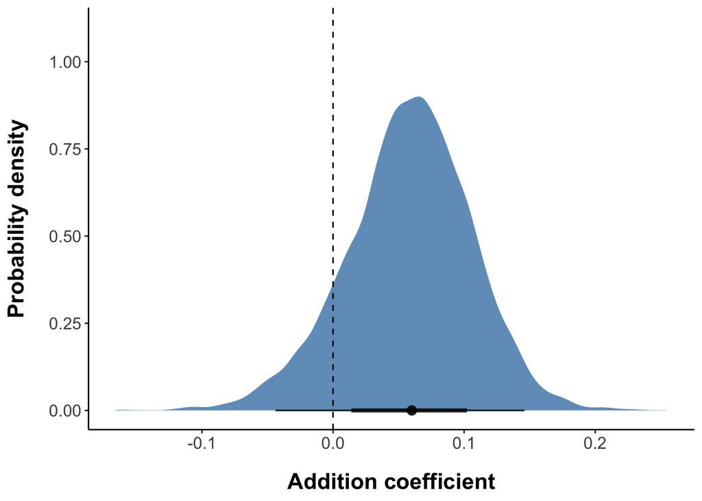

```r
# Plot basics:

post_p <- posterior_samples(val_mdl_weaker) %>%
  ggplot(aes(x = b_typeadd)) +
  stat_halfeye(fill = 'steelblue', alpha = 0.8) +
  geom_vline(xintercept = 0, linetype = 'dashed')
# Axis and labels:

post_p <- post_p +
  xlab('Addition coefficient') +
  ylab('Probability density') +
  coord_cartesian(y = c(0, 1.1)) +
  scale_y_continuous(breaks = seq(0, 1, 0.25))

# Cosmetics:

post_p <- post_p +
  theme_classic() +
  theme(axis.text.x = element_text(size = 12),
        axis.text.y = element_text(size = 12),
        axis.title.x = element_text(face = 'bold', size = 16,
                                    margin = margin(t = 15)),
        axis.title.y = element_text(face = 'bold', size = 16,
                                    margin = margin(r = 15)))

# Show:

post_p
```

Plot posteriors, stronger:

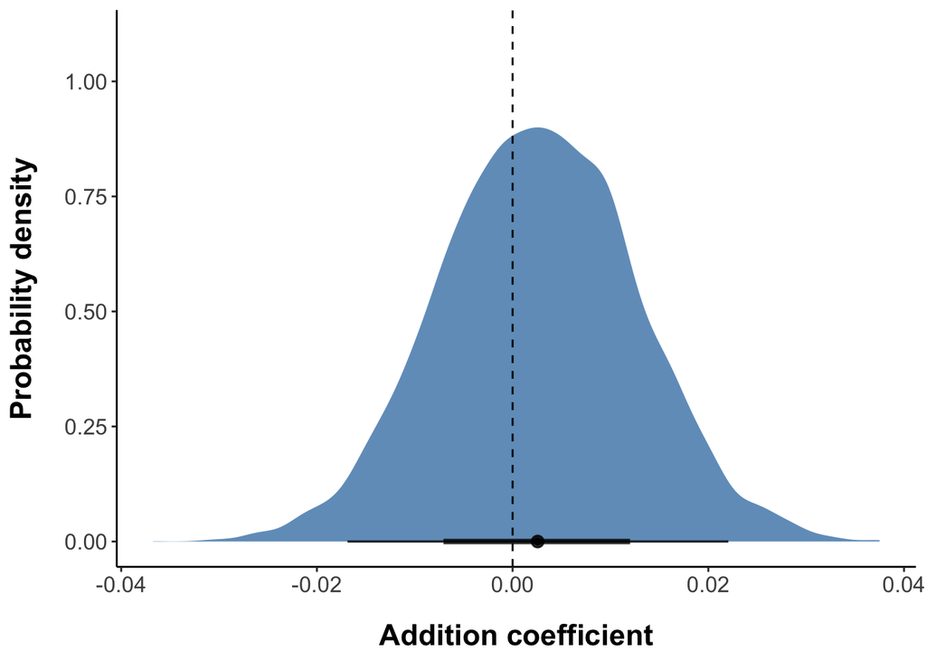

```r
# Plot basics:

post_p <- posterior_samples(val_mdl_stronger) %>%
  ggplot(aes(x = b_typeadd)) +
  stat_halfeye(fill = 'steelblue', alpha = 0.8) +
  geom_vline(xintercept = 0, linetype = 'dashed')
# Axis and labels:

post_p <- post_p +
  xlab('Addition coefficient') +
  ylab('Probability density') +
  coord_cartesian(y = c(0, 1.1)) +
  scale_y_continuous(breaks = seq(0, 1, 0.25))

# Cosmetics:

post_p <- post_p +
  theme_classic() +
  theme(axis.text.x = element_text(size = 12),
        axis.text.y = element_text(size = 12),
        axis.title.x = element_text(face = 'bold', size = 16,
                                    margin = margin(t = 15)),
        axis.title.y = element_text(face = 'bold', size = 16,
                                    margin = margin(r = 15)))

# Show:

post_p
```

Plot posteriors, more stronger:

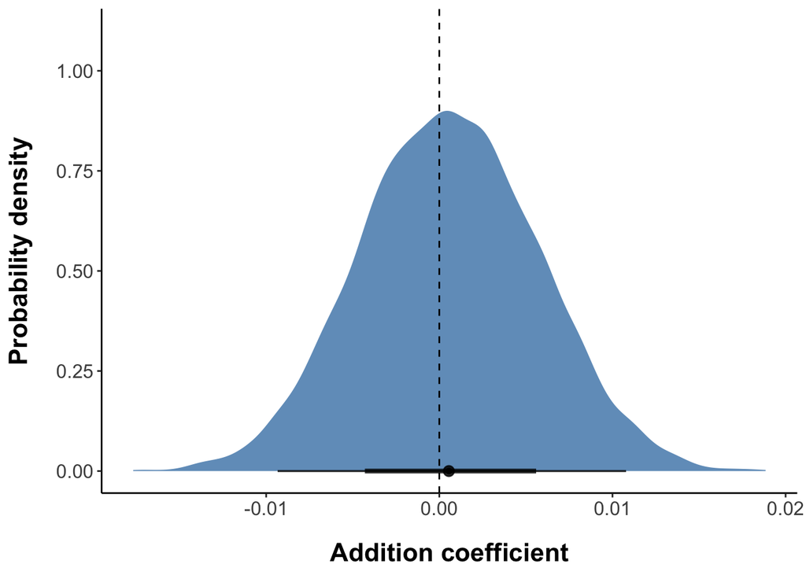

```r
# Plot basics:

post_p <- posterior_samples(val_mdl_more_stronger) %>%
  ggplot(aes(x = b_typeadd)) +
  stat_halfeye(fill = 'steelblue', alpha = 0.8) +
  geom_vline(xintercept = 0, linetype = 'dashed')
# Axis and labels:

post_p <- post_p +
  xlab('Addition coefficient') +
  ylab('Probability density') +
  coord_cartesian(y = c(0, 1.1)) +
  scale_y_continuous(breaks = seq(0, 1, 0.25))

# Cosmetics:

post_p <- post_p +
  theme_classic() +
  theme(axis.text.x = element_text(size = 12),
        axis.text.y = element_text(size = 12),
        axis.title.x = element_text(face = 'bold', size = 16,
                                    margin = margin(t = 15)),
        axis.title.y = element_text(face = 'bold', size = 16,
                                    margin = margin(r = 15)))

# Show:

post_p
```